# GeoSOM de A à Z

Raphaël Bubloz

Mars 2019

# Test du GeoSOM pour un clustering spatial de A à Z

Les principales étapes sont:

- Récupération des données dans la bdd selon un rectangle prédéfini
- Tri des variables (Feature Selection) grâce à la dimension intrinsèque (package `IDmining`)
- Calcul du centroïde des entités et extraction des coordonnées
- Transformation pour passage en `python`
- GeoSOM sur les données
- Différentes comparaisons de clustering:
  - K-Means et CAH sur l’ensemble des données
  - K-Means et CAH sur une SOM attributaire
  - K-Means et CAH sur la GeoSOM

## Récupération des données

Etapes:

- Chargement des librairies
- Création de la connexion
- Récupération des bâtiments selon un rectangle
- Déconnexion de la BD

```r
library("rpostgis")
library("sf")
library("tidyverse")
library('RColorBrewer')
```

Connexion à la DB

```r
conn <- dbConnect("PostgreSQL", dbname = 'essai_clus', host = 'localhost', user = 'postgres', password = '$asd$')
```

Récupération des bâtiments

```r
# Définition du rectangle
limits <- "ST_SetSRID(ST_GeomFromText('Polygon((535650 154830, 535637 153271, 537939 153222, 537899 154823, 535650 154830))'), 21781)"

# Création de la requête
req_bldg <- paste0("SELECT * FROM indic_bldg WHERE ST_Intersects(geom, ", limits, ");")

# Import et suppression des coordonnées Z et M
buildings_import <- st_read(conn, query = req_bldg) %>%
                      st_zm(drop = T)

# Préparation du df (id en rownames)
buildings_df <- st_set_geometry(buildings_import, NULL) %>%
                  remove_rownames() %>%
                  column_to_rownames(var = "id")
```

*img removed*

Déconnexion de la BD

```r
dbDisconnect(conn)
```

## Feature Selection

Etapes:

### A CLARIFIER !

```r
library("IDmining")
```

```r
#lnmMI <- logMINDEX(buildings_df, 1:(ncol(buildings_df)))
#dev.new(width=5, height=4)
#plot(exp(lnmMI[,1]),exp(lnmMI[,2]),pch=19,col="black",xlab="",ylab="")
#title(xlab = expression(delta), cex.lab = 1.5,line = 2.5)
#title(ylab = expression(I['2,'*delta]), cex.lab = 1.5,line = 2.5)
#
#dev.new(width=5, height=4)
#plot(lnmMI[,1],lnmMI[,2],pch=19,col="black",xlab="",ylab="")
#title(xlab = expression(paste("log(",delta,")")), cex.lab = 1.5,line = 2.5)
#title(ylab = expression(paste("log(",I['2,'*delta],")")), cex.lab = 1.5,line = 2.5)
#
#####
#
#
#bf_select <- MBRM(buildings_df, 1:(ncol(buildings_df)))
#
#var_order <- bf_select[[2]]
#var_perf  <- bf_select[[3]]
#
#dev.new(width=5, height=4)
#plot(var_perf,type="b",pch=16,lwd=2,xaxt="n",xlab="", ylab="",
#     col="red",ylim=c(0,max(var_perf)),panel.first={grid(lwd=1.5)})
#axis(1,1:length(var_order),labels=var_order)
#mtext(1,text="Added Features (from left to right)",line=2.5,cex=1)
#mtext(2,text="Estimated ID",line=2.5,cex=1)
```

```r
#test_df <- st_set_geometry(buildings_import, NULL)
#test_df <- test_df[,2:7]

#test_b <- Butterfly()
#plot(logMINDEX(test_b))
#
#lnmMI <- logMINDEX(test_b, 1:10)
#dev.new(width=5, height=4)
#plot(exp(lnmMI[,1]),exp(lnmMI[,2]),pch=19,col="black",xlab="",ylab="")
#title(xlab = expression(delta), cex.lab = 1.5,line = 2.5)
#title(ylab = expression(I['2,'*delta]), cex.lab = 1.5,line = 2.5)
#
#MBRM(test_df)
```

## Ajout des coordonnées X et Y des centroides de bâtiments

```r
# Fonction d'extraction des coords d'un centroide
# Prend une géométrie et une coordonnée (1 pour x, 2 pour y)
extract_cent_coord <- function(geom, coord){
  coords <- st_coordinates(st_centroid(geom))
  return(round(coords[coord], 1))
}

# Ajustement du dataframe pour avoir id, x, y aux 3 premières colonnes
buildings_coords <- buildings_import %>%
                    rowwise() %>%
                    mutate(x = extract_cent_coord(geom, coord = 1),
                           y = extract_cent_coord(geom, coord = 2)) %>%
                    select(id, x, y, everything())
```

## Standardisation et exportation en TSV

**CHANGER LES COLONNES UNE FOIS IDMINING UTILISE !!!**

```r
range01 <- function(x){(x-min(x))/(max(x)-min(x))}

buildings_coords[, 4:(ncol(buildings_coords)-1)] <- lapply(buildings_coords[, 4:(ncol(buildings_coords)-1)], function(x) range01(x))

buildings_coords <- buildings_coords[, -ncol(buildings_coords)]


write.table(buildings_coords[, 1:10], "buildings_sample.tsv", row.names = F, sep = "\t")
write.table(buildings_coords, "buildings.tsv", row.names = F, sep = "\t")
```

## GEOSOM python

A défaut de réussir à utiliser `reticulate` avec un package perso, l’analyse est effectuée dans un *notebook jupyter*

## Clustering

Préparation du jeu de données pour les différentes analyses

```r
blds_an <- buildings_coords[,4:(ncol(buildings_coords)-1)]
blds_fin <- buildings_import[,1]
```

### K-Means sur attributs

On réalise plusieurs Kmeans afin de déterminer quel K vaut plus la peine

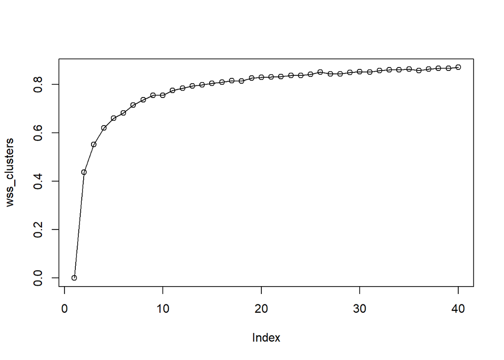

```r
wss_clusters = seq_len(40)
for (i in 1:40) {
    d = kmeans(blds_an, i, nstart=5, iter.max = 50)
    wss_clusters[i] = d$betweenss / d$totss
}
plot(wss_clusters, type="o")
```

On réalise donc un kmeans avec k = 7

```r
kms_att <-  kmeans(blds_an, 7, nstart=5, iter.max = 50)
round(kms_att$betweenss / kms_att$totss, 2)
```

```
## [1] 0.72
```

On peut faire la cartographie du résultat

```r
blds_fin$kms_attr <- factor(kms_att$cluster)
plot(blds_fin[, "kms_attr"], border = NA)
```

*img removed*

### CAH sur attributs

Il faut effectuer un dendrogramme sur les distances entre bâtiments

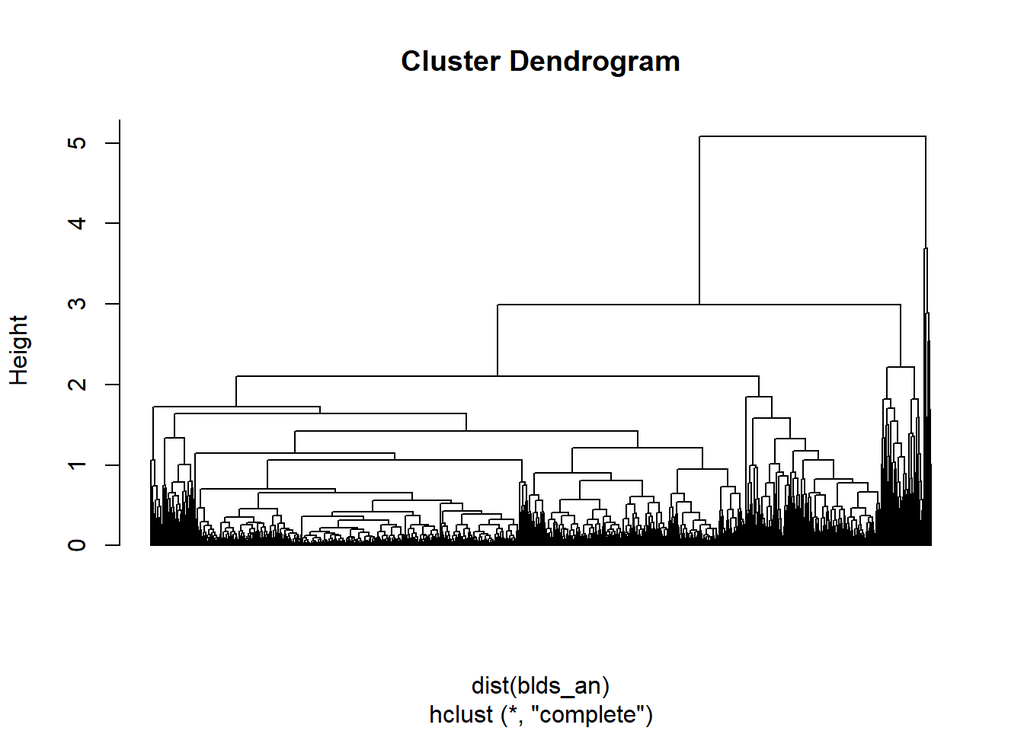

```r
cah_attrib <- hclust(dist(blds_an))
plot(cah_attrib,hang = -1, labels = F)
```

Il faut ensuite déterminer à combien de groupes découper le dendrogramme

```r
blds_fin$cah_attr <- factor(cutree(cah_attrib, k=7))
plot(blds_fin[, "cah_attr"], border = NA)
```

*img removed*

### SOM attributaire

```r
library('kohonen')

data_mat <- as.matrix(blds_an)

grid_att <- somgrid(xdim = 43, ydim = 37, topo = "rectangular", neighbourhood.fct = "gaussian")
som_att <- supersom(data_mat, grid = grid_att)
som_att_cod <- som_att$codes[[1]]
```

#### K-Means sur la SOM

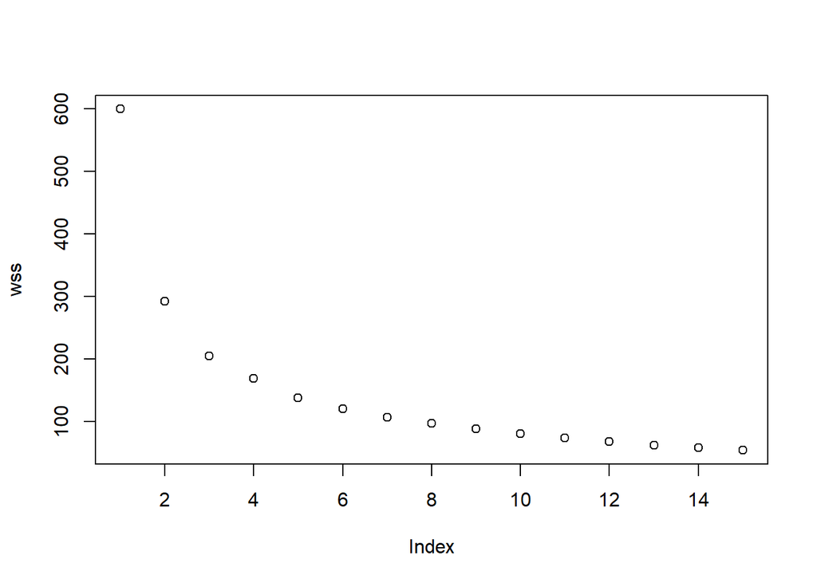

```r
wss <- (nrow(som_att_cod)-1)*sum(apply(som_att_cod,2,var))
for (i in 2:15) {
  wss[i] <- sum(kmeans(som_att_cod, centers=i, nstart = 100L, iter.max = 100)$withinss)
}
plot(wss)
```

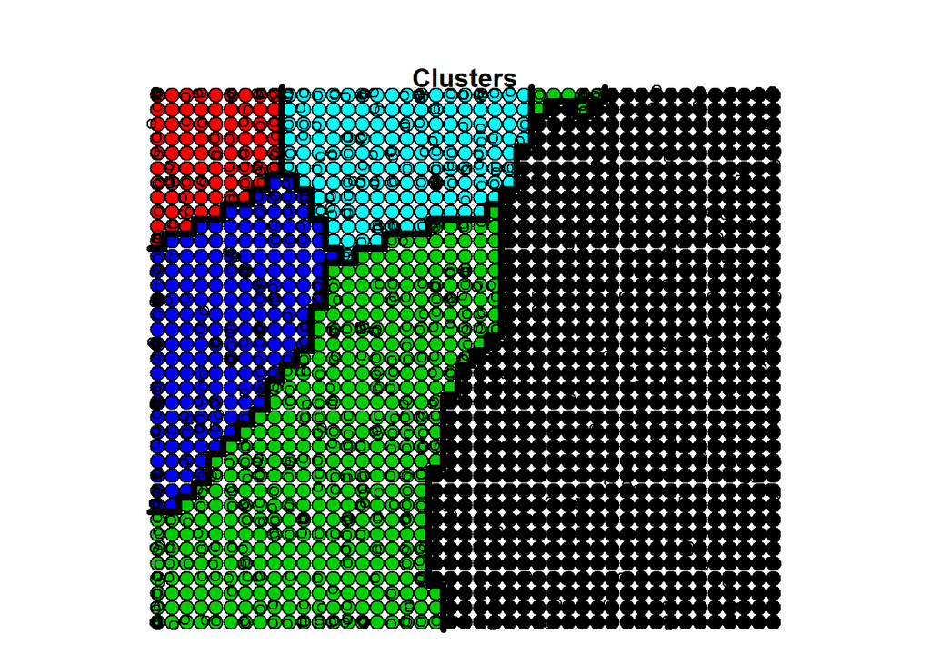

```r
km_som_att <- kmeans(som_att_cod, 5, nstart = 100L)

plot(som_att, type = "mapping", bgcol = palette()[km_som_att$cluster], main = "Clusters")
add.cluster.boundaries(som_att, km_som_att$cluster)
```

```r
km_som_rslt <- km_som_att$cluster[som_att$unit.classif]

blds_fin$km_som <- factor(km_som_rslt)

plot(blds_fin[,"km_som"], border = NA)
```

*img removed*

#### CAH sur la SOM

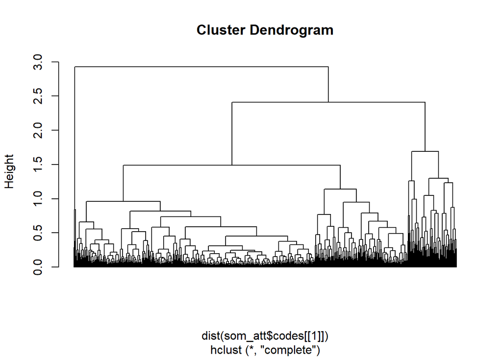

```r
plot(hclust(dist(som_att$codes[[1]])), hang = -1, labels = F)
```

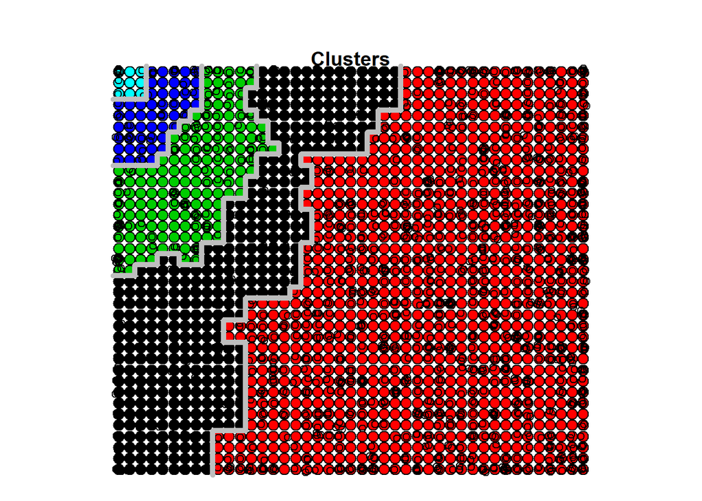

```r
cah_som <- cutree(hclust(dist(som_att$codes[[1]])), 5)

plot(som_att, type = "mapping", bgcol = palette()[cah_som], main = "Clusters")
add.cluster.boundaries(som_att, cah_som, col = "gray")
```

```r
cah_som_rslt <- cah_som[som_att$unit.classif]

blds_fin$cah_som <- factor(cah_som_rslt)

plot(blds_fin[,"cah_som"], border = NA)
```

*img removed*

### GeoSOM

La Geo-SOM est réalisée en python

#### K-Means sur la GeoSOM

```r
cats <- read.csv("rslt_geosom.csv", header = FALSE, col.names = "cat")
cats_geo <- read.csv("rslt_geosom_geo.csv", header = FALSE, col.names = "cat")

buildings_rslt <- buildings_import

buildings_rslt$cats <- cats$cat
buildings_rslt$cats <- factor(buildings_rslt$cats)

buildings_rslt$cats_geo <- cats_geo$cat
buildings_rslt$cats_geo <- factor(buildings_rslt$cats_geo)

plot(buildings_rslt[, "cats"], border = NA)
```

*img removed*

```r
plot(buildings_rslt[, "cats_geo"], border = NA)
```

*img removed*

```r
plot(buildings_rslt$geom, col = "gray93", border = NA)
```

*img removed*

#### CAH sur la GeoSOM

```r
cah_cats <- read.csv("rslt_geosom_cah.csv", header = FALSE, col.names = "cat")
cah_cats_geo <- read.csv("rslt_geosom_cah_geo.csv", header = FALSE, col.names = "cat")

#buildings_rslt <- buildings_import

buildings_rslt$cah_cats <- cah_cats$cat
buildings_rslt$cah_cats <- factor(buildings_rslt$cah_cats)

buildings_rslt$cah_cats_geo <- cah_cats_geo$cat
buildings_rslt$cah_cats_geo <- factor(buildings_rslt$cah_cats_geo)

plot(buildings_rslt[, "cah_cats"], border = NA)
```

*img removed*

```r
plot(buildings_rslt[, "cah_cats_geo"], border = NA)
```

*img removed*

```r
plot(buildings_rslt$geom, col = "gray93", border = NA)
```

*img removed*

##### Reste

Export pdf

#### DBSCAN

```r
library('dbscan')
```

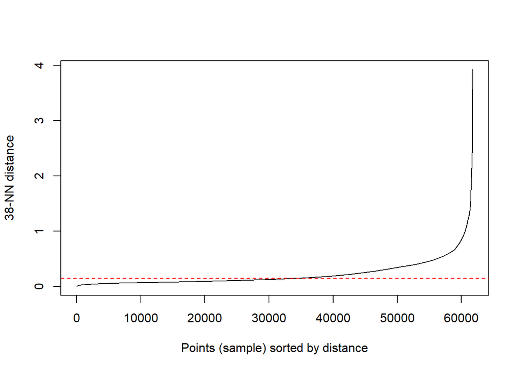

```r
dbs_data <- buildings_coords[, - c(1:3)]

kNNdistplot(dbs_data, k = 38)
abline(h = 0.15, col = 'red', lty = 2)
```

```r
res_stata <- dbscan(dbs_data, eps = 0.15, minPts = 5)

buildings_rslt$TESTTEST <- res_stata$cluster

plot(buildings_rslt[, "TESTTEST"], border = NA, main = "DB SCAN")
```

*img removed*

```r
table(res_stata$cluster)
```

```
##
##    0    1    2    3    4    5    6
##  412 1176   12    8    7    5    6
```